# Road risk study cases

Hola, esto es un Rmarkdown para mostrarte lo de roads.

Estuve viendo el índice que hicimos y tenía dudas de cómo hacer el de `future roads` porque ahora tenemos es un `risk assessment`. Al final lo que hice fue sumar todos los risks de las especies:

$$Road\ risk = \sum{{species\ risk}_i}$$

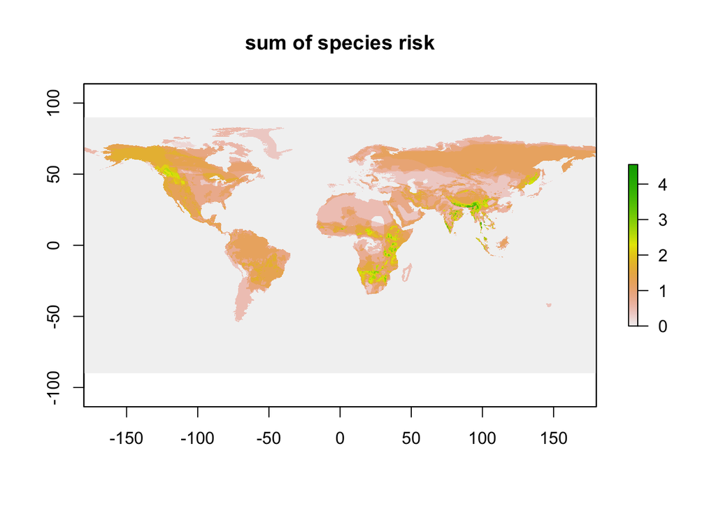

En el índice anterior le habíamos agregado también PA, que ya no me convence mucho. Para sumarlo, al pixel que fuera PA le dimos un valor (peso) igual a la especie con menos riesgo. O sea, como si PA fuera una especie más.

$$Road\ risk = \sum{{species\ risk}_i} + \min({species\ risk}_i)*PA$$

en donde PA tiene valores de 0 o 1 (i.e., $PA \in \{0,1\}$).

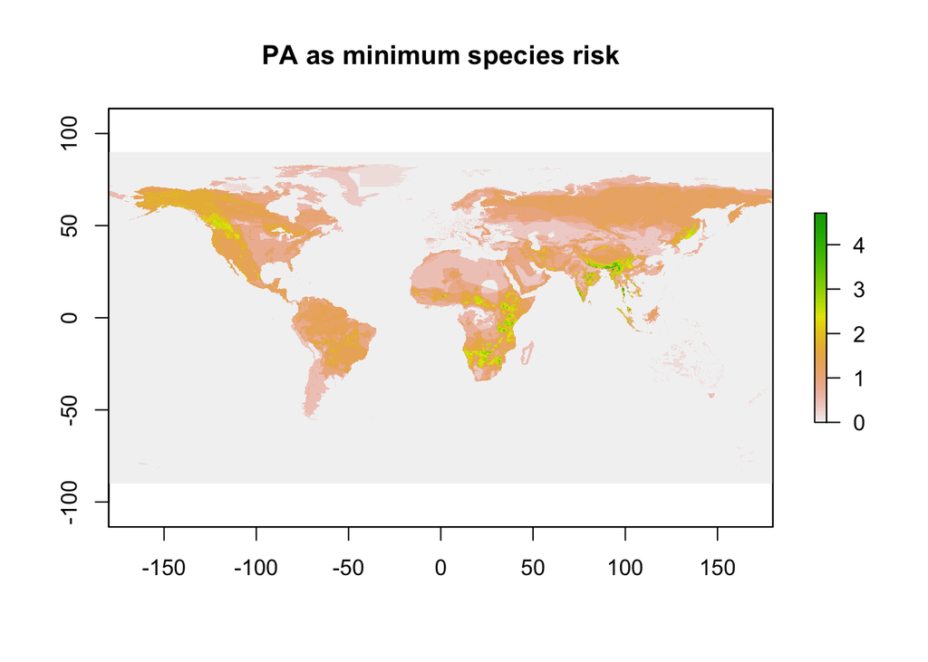

Como me gusta sin PA porque las áreas no protegidas entonces pierden valor, pero no sé ¿qué te parece?

> Update: pensándolo más, el peso de PAs podría ser el promedio de el riesgo de las especies presentes en ese pixel. Igual va a bajarle el valor a las no protegidas.

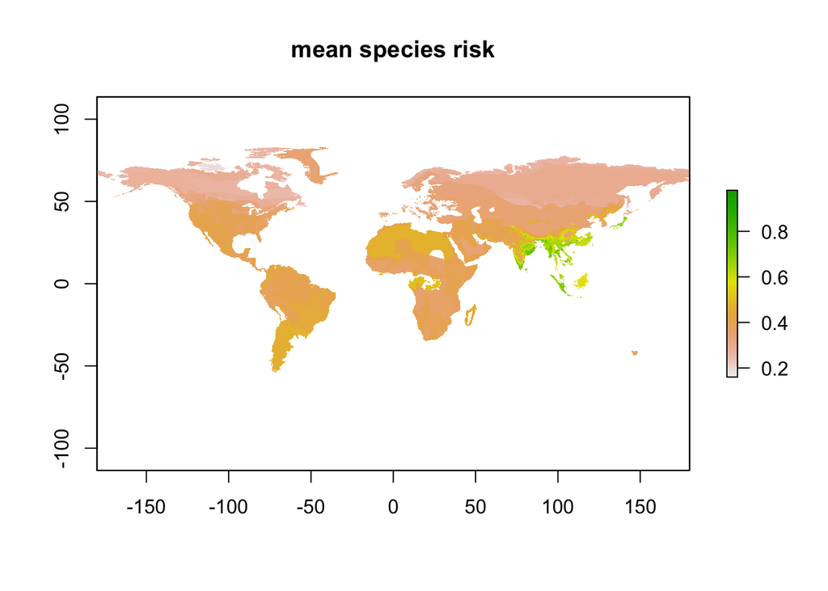

```r
plot(rkm, main='mean species risk')
```

$$Road\ risk = \sum{{species\ risk}_i} + \left(\frac{\sum{{species\ risk}_i}}{n}\right)*PA$$

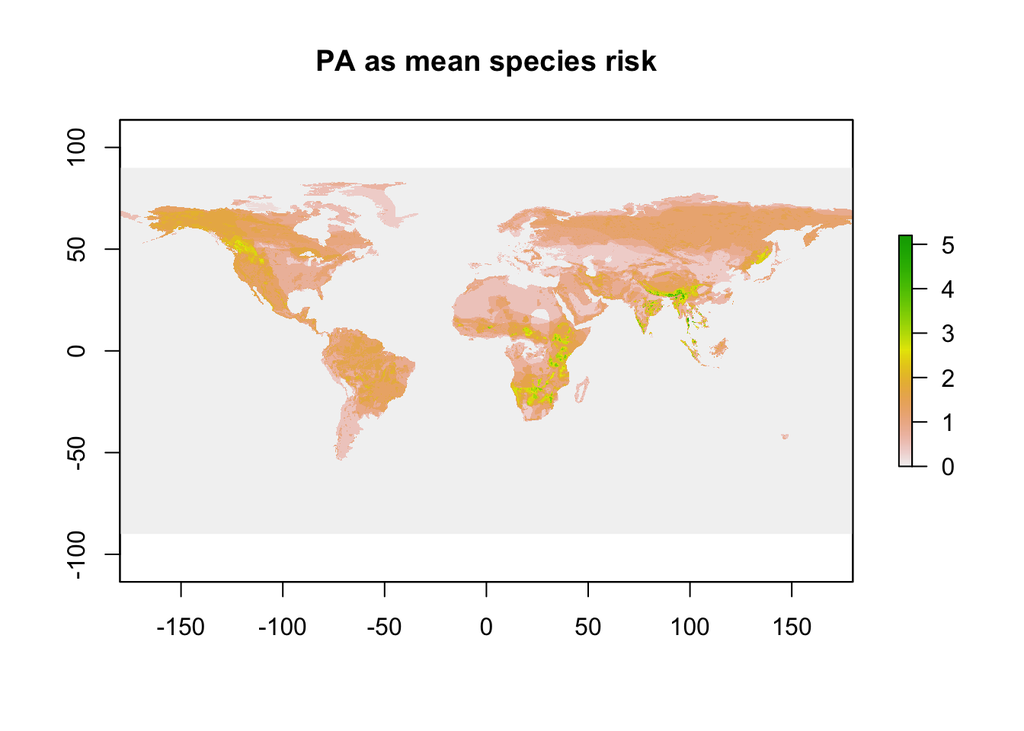

```r
rkm.PA <-  sum(rks, rkm*PA, na.rm = T)
plot(rkm.PA, main='PA as mean species risk')
```

Así se ve en nuestras study areas.

```r
library(cowplot)
library(sf)
e.af <- extent(c(-17.53604, 52, -34.81917, 19-0.32991))
e.br <- extent(c(-75.18, -43.18, -16.39-2-.55077, 6.29-2))+6
e.np <- extent(c(79.08, 89.17, 23.3, 30.6))+2

rks.af <- crop(rks,e.af)
rks.br <- crop(rks,e.br)
rks.np <- crop(rks,e.np)

rks.PA.af <- crop(rks.PA,e.af)
rks.PA.br <- crop(rks.PA,e.br)
rks.PA.np <- crop(rks.PA,e.np)

rkm.PA.af <- crop(rkm.PA,e.af)
rkm.PA.br <- crop(rkm.PA,e.br)
rkm.PA.np <- crop(rkm.PA,e.np)

risk.af <- st_read('data/index_spp/risk_line_AF')
risk.br <- st_read('data/index_spp/risk_line_BR')
risk.np <- st_read('data/index_spp/risk_line_NP')
```

# Africa

## sum risks

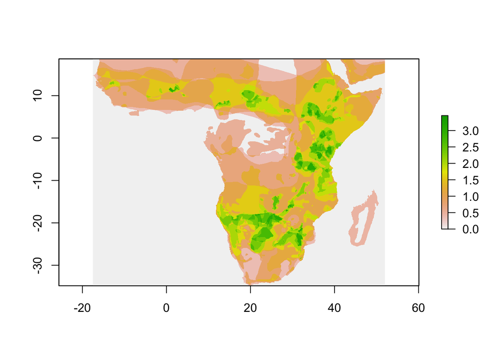

```r
plot(rks.af, zlim=c(0,maxValue(rkm.PA.af)))
```

## sum risks con min·PA

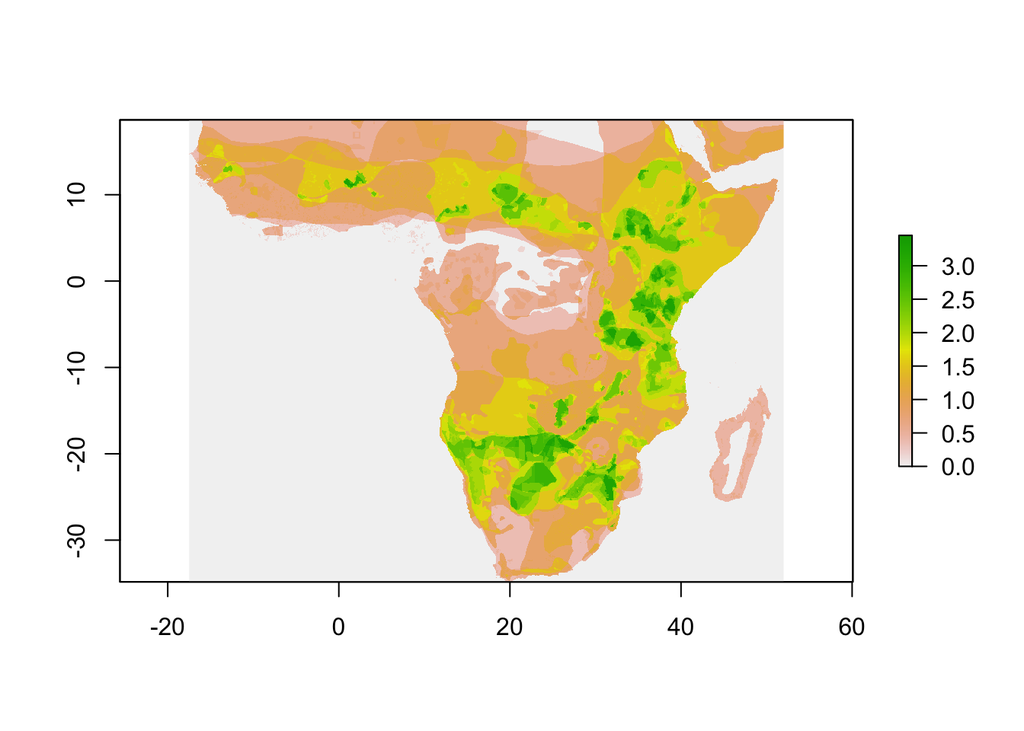

```r
plot(rks.PA.af, zlim=c(0,maxValue(rkm.PA.af)))
```

## sum risks con mean·PA

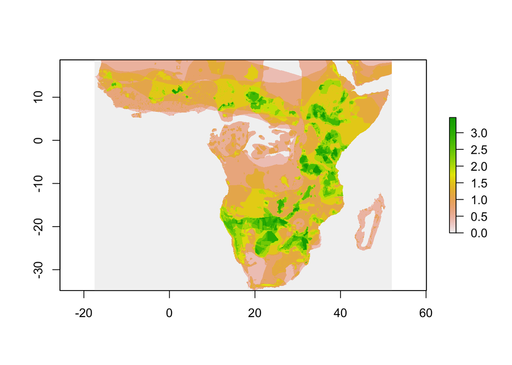

```r
plot(rkm.PA.af, zlim=c(0,maxValue(rkm.PA.af)))
```

# Brazil

## sum risks

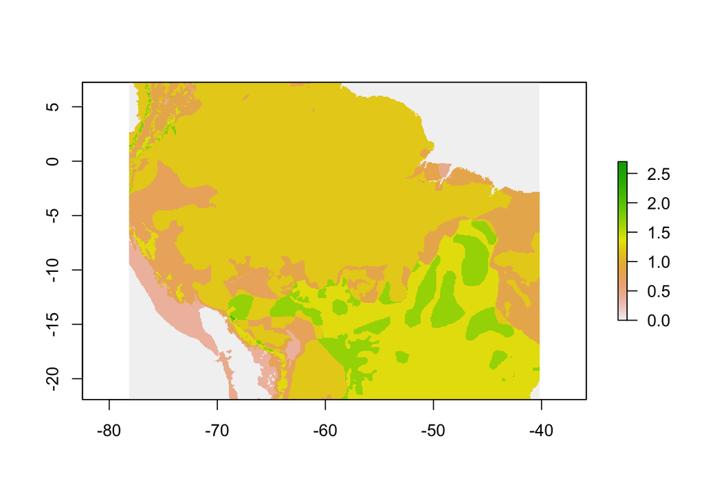

```r
plot(rks.br, zlim=c(0,maxValue(rkm.PA.br)))
```

## sum risks con min·PA

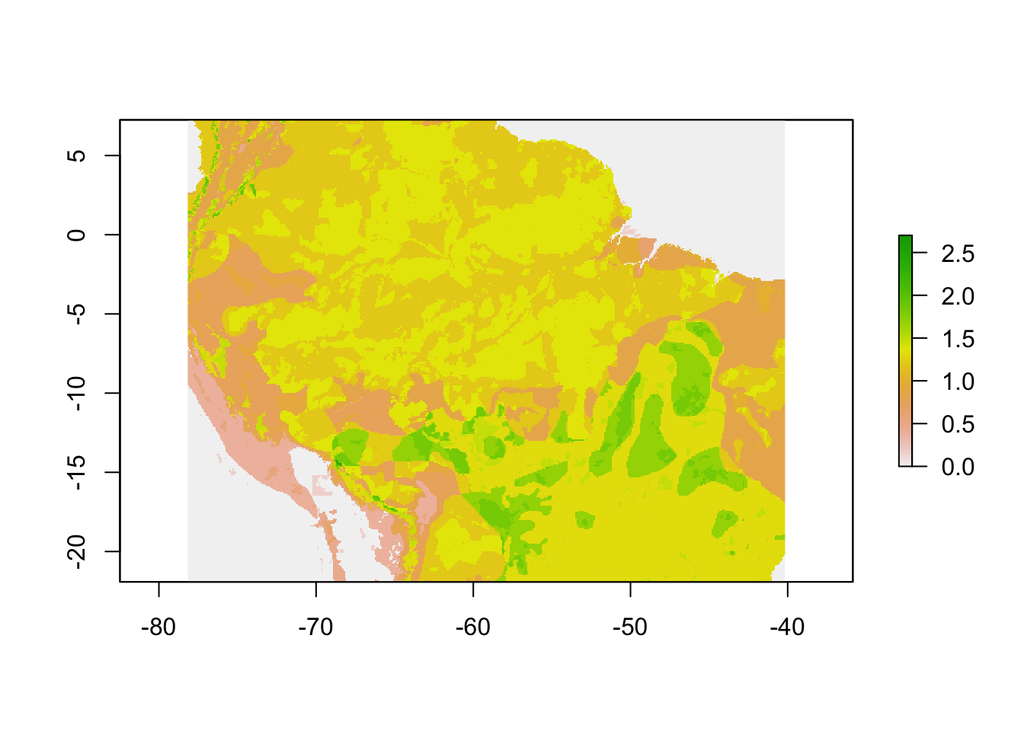

```r
plot(rks.PA.br, zlim=c(0,maxValue(rkm.PA.br)))
```

## sum risks con mean·PA

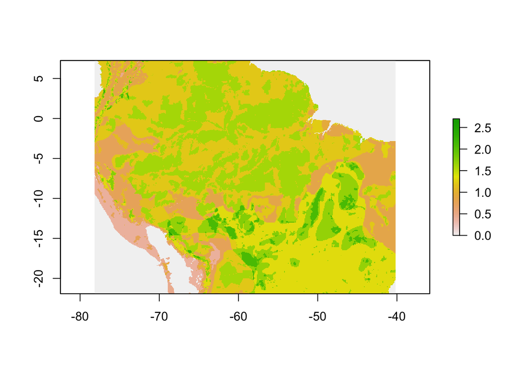

```r
plot(rkm.PA.br, zlim=c(0,maxValue(rkm.PA.br)))
```

# Nepal

## sum risks

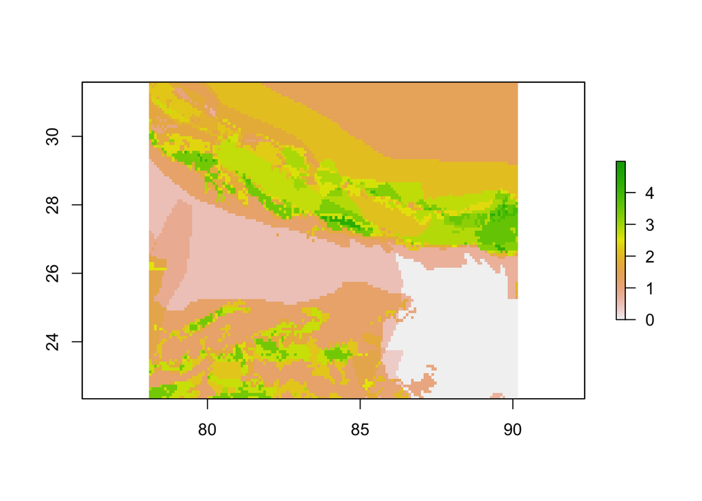

```r
plot(rks.np, zlim=c(0,maxValue(rkm.PA.np)))
```

## sum risks con min·PA

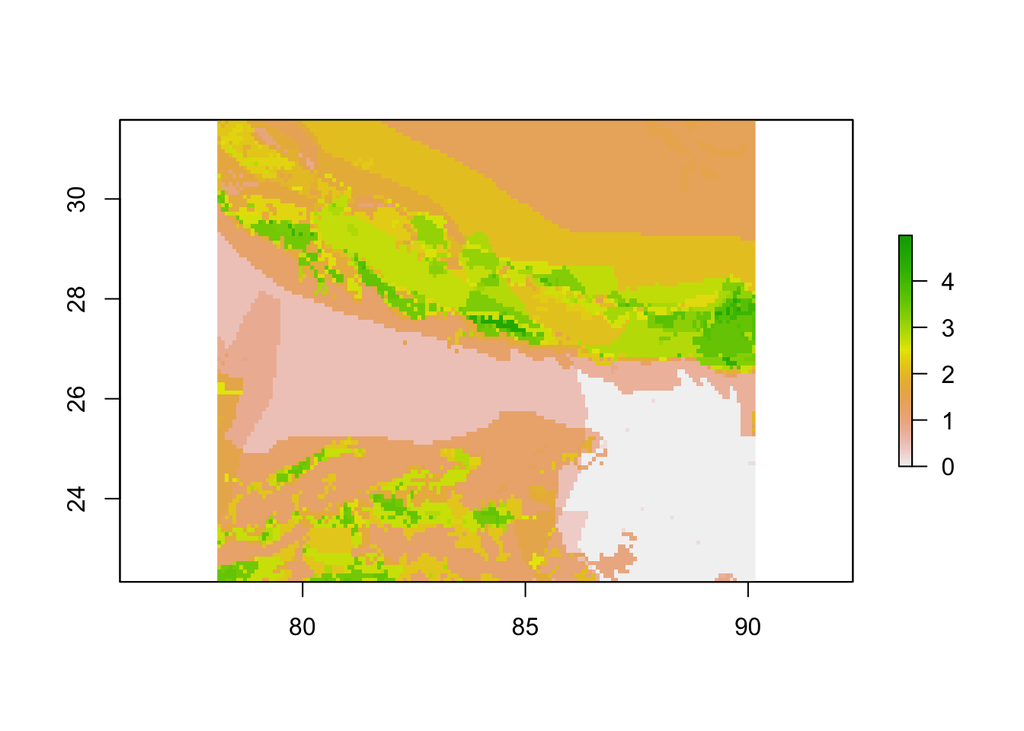

```r
plot(rks.PA.np, zlim=c(0,maxValue(rkm.PA.np)))
```

## sum risks con mean·PA

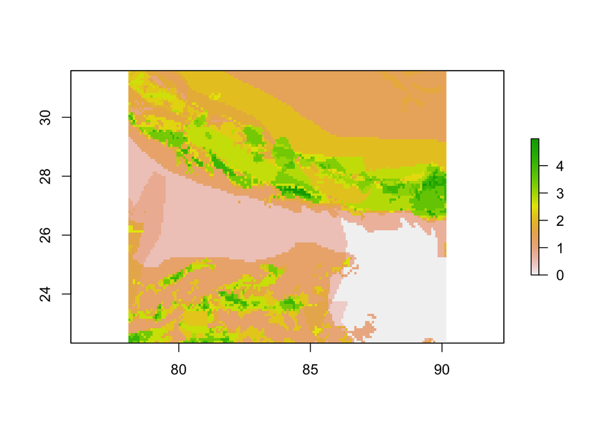

```r
plot(rkm.PA.np, zlim=c(0,maxValue(rkm.PA.np)))
```

# Road Risk

Ahora, así se vería el risk en la carretera (sin PA):

> tengo que actualizarlas con min·PA y con mean·PA

## Africa

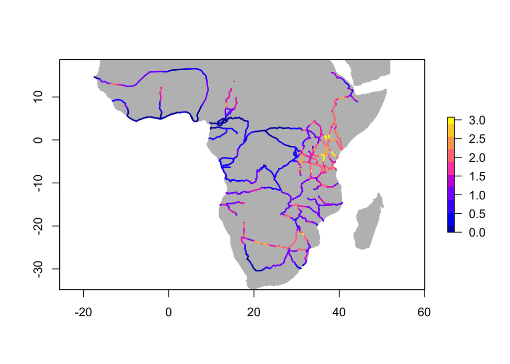

```r
plot(crop(rk.land, e.af), col='grey', legend=F)
plot(rks.af, col=sf.colors(10), legend.only=T)
plot(risk.af[,'layer'], lwd=2, add=T, )
```

## Brazil

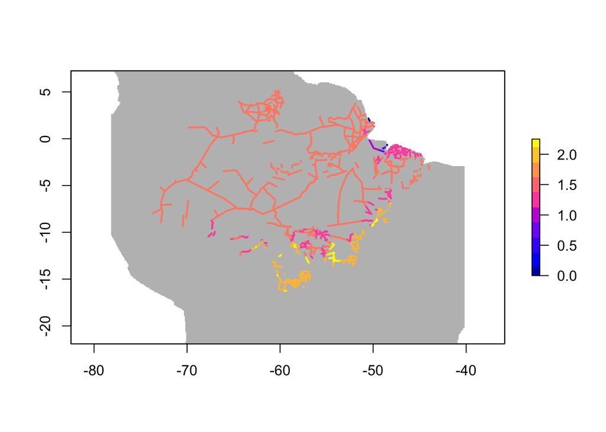

```r
plot(crop(rk.land, e.br), col='grey', legend=F)
plot(rks.br, col=sf.colors(10), legend.only=T)
plot(risk.br[,'layer'], lwd=2, add=T, )
```

## Nepal

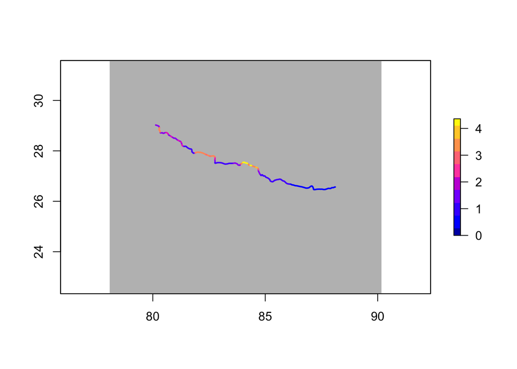

```r
plot(crop(rk.land, e.np), col='grey', legend=F)
plot(rks.np, col=sf.colors(10), legend.only=T)
plot(risk.np[,'layer'], lwd=2, add=T, )
```